# Homework 2 Report

### Model Performance

```r
# See "R/utils-confmat.R" for helper function definitions.
# Find predictions and make misclassification table.
p.threshold = 0.5
liver.prediction <- (liver.fit$fitted >= p.threshold)
liver.truth <- map.where(liver$severity == "1")
Classif.table <- table(liver.prediction, liver.truth)
knitr::kable(Classif.table)
```

|  | FALSE | TRUE |
| --- | --- | --- |
| FALSE | 165 | 67 |
| TRUE | 35 | 78 |

[output not shown]

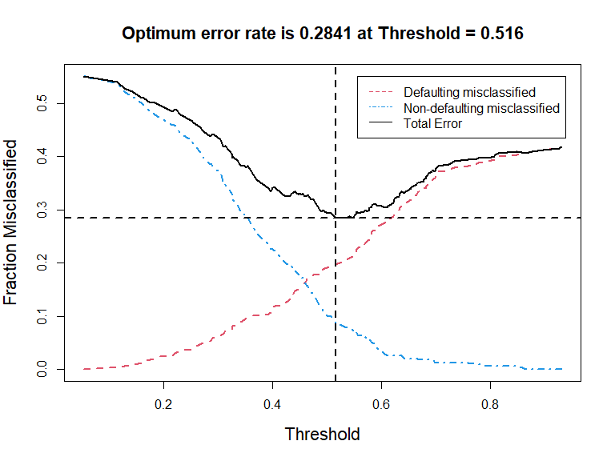

```r
liver.ERR.rates <- All.error.rates.f(
  Truth = (liver$severity == "1"),
  Pred = liver.fit$fitted
)
Plot.Error.f(lista = liver.ERR.rates, cex=1.4)
```

As shown by the plot, the total error rate is optimized when the threshold is $\approx 0.516$. The misclassification for the optimal case:

```r
p.threshold = 0.516
liver.prediction <- (liver.fit$fitted >= p.threshold)
liver.truth <- map.where(liver$severity == "1")
Classif.table <- table(liver.prediction, liver.truth)
knitr::kable(Classif.table)
```

|  | FALSE | TRUE |
| --- | --- | --- |
| FALSE | 170 | 68 |
| TRUE | 30 | 77 |

## Cross-Valdiation

We use the following settings for our CV runs:

```r
k.folds = c(10,3)
t.limit = c(0.001, 1.0)
n.thresholds = 200
n.rounds = 100
```

### $k = 10$ -fold CV

Below is a 10-fold cross-validation, using 100 rounds:

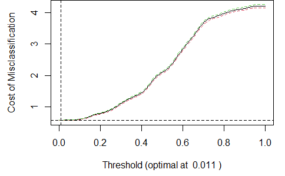

| Minimum Cost | Minimum Threshold |
| --- | --- |
| 0.5706697 | 0.0110402 |

```
$Mean
       [,1]   [,2]
[1,] 144.88 141.63
[2,] 158.07 144.99

$StErr
          [,1]    [,2]
[1,] 1.4020389 1.43017
[2,] 0.8825188 0.01000
```

### $k = 3$ -fold CV

Below is a 3-fold cross-validation, using 100 rounds:

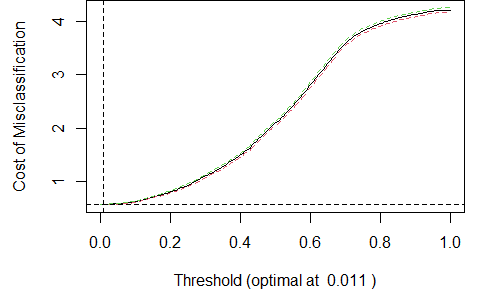

| Minimum Cost | Minimum Threshold |
| --- | --- |
| 0.5727536 | 0.0110402 |

```
$Mean
       [,1]   [,2]
[1,]  58.65  55.09
[2,] 183.07 144.79

$StErr
         [,1]       [,2]
[1,] 4.338723 4.37465369
[2,] 1.290075 0.04333333
```

## Session Information

*This document was generated from an [R Markdown](http://rmarkdown.rstudio.com) Notebook (See the `vignettes/HW2_report.Rmd` in the package’s sub-directory). The setup chunk for this document sets the root directory to the project root directory using the `rprojroot` package; all file paths are relative to the project root.*